# Case Study: Smart Reply Implemented as Nueral Question Answer

## **About Dataset:**

Data Stanford Question Answering Dataset (SQuAD) is a reading comprehension dataset, consisting of questions posed by crowdworkers on a set of Wikipedia articles, where the answer to every question is a segment of text, or span, from the corresponding reading passage, or the question might be unanswerable. You can download this dataset here https://rajpurkar.github.io/SQuAD-explorer/

**SQuAD 1.1**: the previous version of the SQuAD dataset, contains 100,000+ question-answer pairs on 500+ articles.

Here I used SQuAD 1.1. Each article contains following structure:

**The Below case study is implemented using the referance from https://arxiv.org/pdf/1704.00051.pdf**

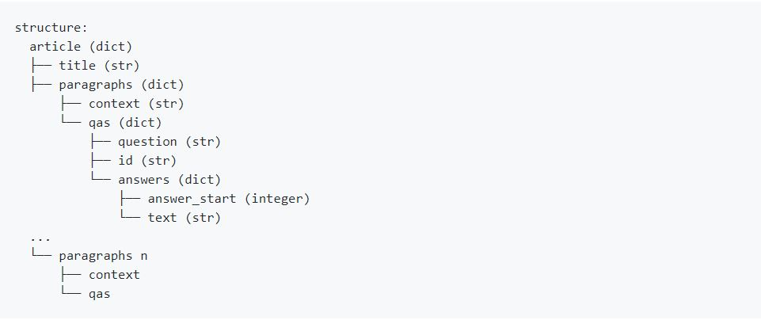

## **Problem Statement**:

Predicting the right answer for the given question and context.

```python
# importing all necessary files
import warnings
warnings.filterwarnings("ignore")
import pandas as pd
import numpy as np
from textblob import TextBlob
import matplotlib.pyplot as plt
%matplotlib inline
import seaborn as sns
from tqdm import tqdm
import json
import re
import nltk
import csv


from langdetect import detect
from pickle import dump,load

import tensorflow as tf
import sys
import datetime
import os
import six

from collections import Counter
import string
import re
import sys
```

[output not shown]

## 1. Preprocessing

```python
train = pd.read_json("SQuAD/train-v1.1.json")
dev = pd.read_json("SQuAD/dev-v1.1.json")

print(train.shape)
print(dev.shape)
```

[output not shown]

```python
dev.head()
```

|  | data | version |
| --- | --- | --- |
| 0 | {'title': 'Super_Bowl_50', 'paragraphs': [{'co... | 1.1 |
| 1 | {'title': 'Warsaw', 'paragraphs': [{'context':... | 1.1 |
| 2 | {'title': 'Normans', 'paragraphs': [{'context'... | 1.1 |
| 3 | {'title': 'Nikola_Tesla', 'paragraphs': [{'con... | 1.1 |
| 4 | {'title': 'Computational_complexity_theory', '... | 1.1 |

```python
# getting train data and dev data into csv file

contexts = []
questions = []
answers_text = []
answers_start = []
title = []
for i in range(train.shape[0]):
    topic = train.iloc[i,0]['paragraphs']
    title_ = train.iloc[i,0]['title']
    for sub_para in topic:
        for q_a in sub_para['qas']:
            questions.append(q_a['question'])
            if len(q_a['answers'])>0 :
                answers_start.append(q_a['answers'][0]['answer_start'])
                answers_text.append(q_a['answers'][0]['text'])
            else:
                answers_start.append(None)
                answers_text.append(None)
            contexts.append(sub_para['context'])
            title.append(title_)

# test data

test_contexts = []
test_questions = []
test_answers_text = []
test_answers_start = []
test_title = []
for i in range(dev.shape[0]):
    topic = dev.iloc[i,0]['paragraphs']
    title_ = dev.iloc[i,0]['title']
    for sub_para in topic:
        for q_a in sub_para['qas']:
            test_questions.append(q_a['question'])
            if len(q_a['answers'])>0 :
                test_answers_start.append(q_a['answers'][0]['answer_start'])
                test_answers_text.append(q_a['answers'][0]['text'])
            else:
                test_answers_start.append(None)
                test_answers_text.append(None)
            test_contexts.append(sub_para['context'])
            test_title.append(title_)
```

```python
train = pd.DataFrame({"context":contexts, "question": questions, "answer_start": answers_start, "text": answers_text,'title':title})
train.dropna(inplace=True)

train.info()
```

```
<class 'pandas.core.frame.DataFrame'>
Int64Index: 87599 entries, 0 to 87598
Data columns (total 5 columns):
context         87599 non-null object
question        87599 non-null object
answer_start    87599 non-null int64
text            87599 non-null object
title           87599 non-null object
dtypes: int64(1), object(4)
memory usage: 4.0+ MB
```

```python
dev = pd.DataFrame({"context":test_contexts, "question": test_questions, "answer_start": test_answers_start, "text": test_answers_text,'title':test_title})
dev.dropna(inplace=True)
dev.info()
```

```
<class 'pandas.core.frame.DataFrame'>
Int64Index: 10570 entries, 0 to 10569
Data columns (total 5 columns):
context         10570 non-null object
question        10570 non-null object
answer_start    10570 non-null int64
text            10570 non-null object
title           10570 non-null object
dtypes: int64(1), object(4)
memory usage: 495.5+ KB
```

```python
train.head()
```

|  | context | question | answer_start | text | title |
| --- | --- | --- | --- | --- | --- |
| 0 | Architecturally, the school has a Catholic cha... | To whom did the Virgin Mary allegedly appear i... | 515 | Saint Bernadette Soubirous | University_of_Notre_Dame |
| 1 | Architecturally, the school has a Catholic cha... | What is in front of the Notre Dame Main Building? | 188 | a copper statue of Christ | University_of_Notre_Dame |
| 2 | Architecturally, the school has a Catholic cha... | The Basilica of the Sacred heart at Notre Dame... | 279 | the Main Building | University_of_Notre_Dame |
| 3 | Architecturally, the school has a Catholic cha... | What is the Grotto at Notre Dame? | 381 | a Marian place of prayer and reflection | University_of_Notre_Dame |
| 4 | Architecturally, the school has a Catholic cha... | What sits on top of the Main Building at Notre... | 92 | a golden statue of the Virgin Mary | University_of_Notre_Dame |

## 2. Data Preprocessing

### 2.1 Text data cleaning

```python
def decontracted(phrase):
    """
    This function remooves punctuation from given sentence.
    """
    # specific
    phrase = re.sub(r"won't", "will not", phrase)
    phrase = re.sub(r"can\'t", "can not", phrase)

    # general
    phrase = re.sub(r"n\'t", " not", phrase)
    phrase = re.sub(r"\'re", " are", phrase)
    phrase = re.sub(r"\'s", " is", phrase)
    phrase = re.sub(r"\'d", " would", phrase)
    phrase = re.sub(r"\'ll", " will", phrase)
    phrase = re.sub(r"\'t", " not", phrase)
    phrase = re.sub(r"\'ve", " have", phrase)
    phrase = re.sub(r"\'m", " am", phrase)

    # string operation
    phrase = phrase.replace('\\r', ' ')
    phrase = phrase.replace('\\"', ' ')
    phrase = phrase.replace('\\n', ' ')

    phrase = re.sub('[^A-Za-z0-9]+', ' ', phrase.lower())

    return phrase


def tokenize(sentence):
    """
    Returns tokenised words.
    """
    return nltk.word_tokenize(sentence)

def answer_span(context,ans):
    """
    This funtion returns anwer span start index and end index.
    """
    ans_token = tokenize(ans)
    con_token = tokenize(context)
    ans_len = len(ans_token)

    if ans_len!=0 and ans_token[0] in con_token:

        indices = [i for i, x in enumerate(con_token) if x == ans_token[0]]
        try:

            if(len(indices)>1):
                start = [i for i in indices if (con_token[i:i+ans_len] == ans_token) ]
                end = start[0] + ans_len - 1
                return start[0],end

            else:
                start = con_token.index(ans_token[0])
                end = start + ans_len - 1
                return start,end
        except:
            return -1,-1
    else:
        return -1,-1
```

1. Context

```python
# for train data

from tqdm import tqdm
preprocessed_context = []
# tqdm is for printing the status bar
for sentance in tqdm(train["context"].values):
    sent = decontracted(sentance)
    preprocessed_context.append(sent.strip())

train["clean_context"] = preprocessed_context

# for dev data
from tqdm import tqdm
dev_preprocessed_context = []
# tqdm is for printing the status bar
for sentance in tqdm(dev["context"].values):
    sent = decontracted(sentance)
    dev_preprocessed_context.append(sent.strip())

dev["clean_context"] = dev_preprocessed_context
```

```python
preprocessed_context[0]
```

```
'architecturally the school has a catholic character atop the main building is gold dome is a golden statue of the virgin mary immediately in front of the main building and facing it is a copper statue of christ with arms upraised with the legend venite ad me omnes next to the main building is the b…
```

1. Qustions

```python
# for train data

from tqdm import tqdm
preprocessed_question = []
# tqdm is for printing the status bar
for sentance in tqdm(train["question"].values):
    sent = decontracted(sentance)
    preprocessed_question.append(sent.strip())

train["clean_question"] = preprocessed_question


# for dev data

from tqdm import tqdm
dev_preprocessed_question = []
# tqdm is for printing the status bar
for sentance in tqdm(dev["question"].values):
    sent = decontracted(sentance)
    dev_preprocessed_question.append(sent.strip())

dev["clean_question"] = dev_preprocessed_question
```

```python
preprocessed_question[:5]
```

```
['to whom did the virgin mary allegedly appear in 1858 in lourdes france',
 'what is in front of the notre dame main building',
 'the basilica of the sacred heart at notre dame is beside to which structure',
 'what is the grotto at notre dame',
 'what sits on top of the main building at notre dame']
```

1. Answers

```python
# for train data

preprocessed_answer = []
# tqdm is for printing the status bar
for sentance in tqdm(train["text"].values):
    sent = decontracted(sentance)
    preprocessed_answer.append(sent.strip())


train["clean_answer"] = preprocessed_answer

# for dev data

dev_preprocessed_answer = []
# tqdm is for printing the status bar
for sentance in tqdm(dev["text"].values):
    sent = decontracted(sentance)
    dev_preprocessed_answer.append(sent.strip())

dev["clean_answer"] = dev_preprocessed_answer
```

### 2.2 Language Detection

The language of the message is iden-tified and non-English messages are discarded.

```python
# function for language detction

def get_language(string):

    """
    This function returns the language of string. Uses Textblob which internally uses google API.

    This creates problem when you have to check for too many values.

    You will get --> 'HTTPError: HTTP Error 429: Too Many Requests'

    @return - language

    """
    return TextBlob(string).detect_language()


def language(string):
    """
    Not as accurate as TextBlob but gets our work done.

    @return - language

    """
    return detect(string)
```

```python
# for train data

train["language"] = train["clean_context"].apply(language)
print(np.unique(train["language"]))

# for dev data

dev["language"] = dev["clean_context"].apply(language)
print(np.unique(dev["language"]))
```

```
['en' 'it' 'pt']
['en']
```

```python
train = train[train["language"] == 'en']
print(train.shape)

dev = dev[dev["language"] == 'en']
print(dev.shape)
```

```
(87595, 9)
(10570, 9)
```

```python
train.info()
```

[output not shown]

### 2.3 Calculating ans span for given ans and context

```python
ans_span = []
for i in range(len(train)):
    s,e = answer_span(train["clean_context"].iloc[i],train["clean_answer"].iloc[i])
    ans_span.append((s,e))

print("number of answer not matching context :- ",ans_span.count((-1,-1)))

train["ans_span"] = ans_span
```

[output not shown]

```python
ans_span = []
for i in range(len(dev)):
    s,e = answer_span(dev["clean_context"].iloc[i],dev["clean_answer"].iloc[i])
    ans_span.append((s,e))

print("number of answer not matching context :- ",ans_span.count((-1,-1)))

dev["ans_span"] = ans_span
```

[output not shown]

```python
print(train.shape)
print(dev.shape)
```

[output not shown]

```python
train = train[train["ans_span"] != (-1,-1)]
dev = dev[dev["ans_span"] != (-1,-1)]
```

```python
print(train.shape)
print(dev.shape)
```

```
(87388, 11)
(10548, 11)
```

## 3. EDA

```python
# adding context_length ,question_length and answer_length features for eda
train["context_length"] = train["clean_context"].apply(lambda x:len(x.split()))
train["question_length"] = train["clean_question"].apply(lambda x:len(x.split()))
train["answer_length"] = train["clean_answer"].apply(lambda x:len(x.split()))
```

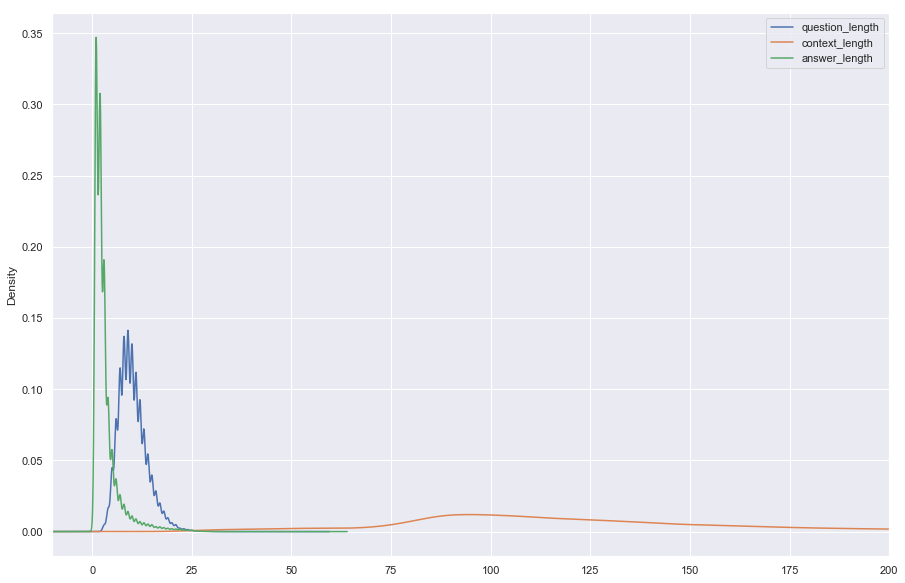

```python
sns.set()
tf = train[["question_length","context_length","answer_length"]]
tf.plot.kde(figsize=(15,10),xlim=(-10,200))
```

1. Train Context Length

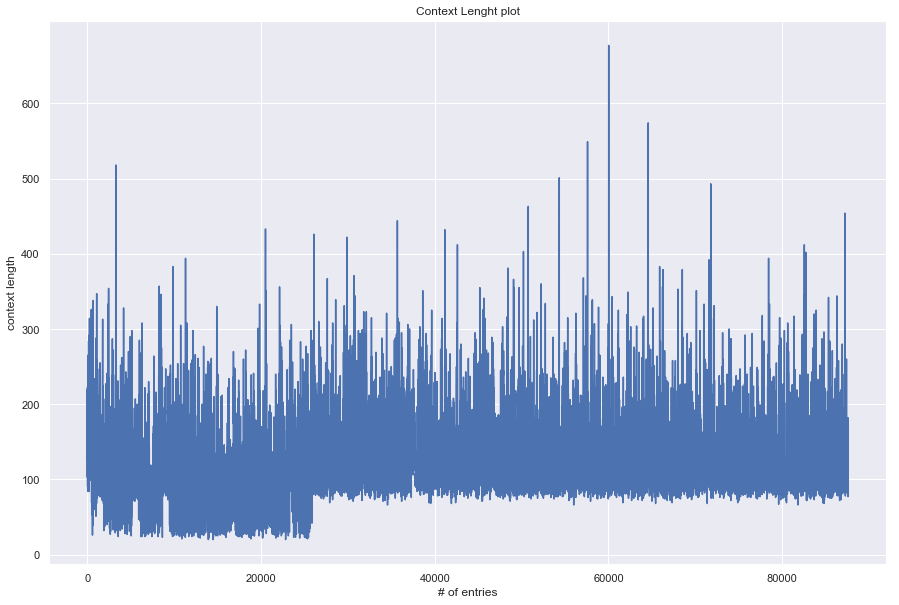

```python
plt.figure(figsize=(15,10))
plt.plot(train["context_length"])
plt.xlabel("# of entries")
plt.ylabel("context length")
plt.yticks(range(0,700,100))
plt.title("Context Lenght plot")
plt.show()
```

1. Train Question Length

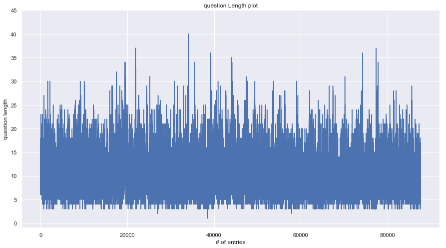

```python
plt.figure(figsize=(15,8))
plt.plot(train["question_length"])
plt.xlabel("# of entries")
plt.ylabel("question length")
plt.yticks(range(0,50,5))
plt.title("question Length plot")
plt.show()
```

1. Answer Length plot

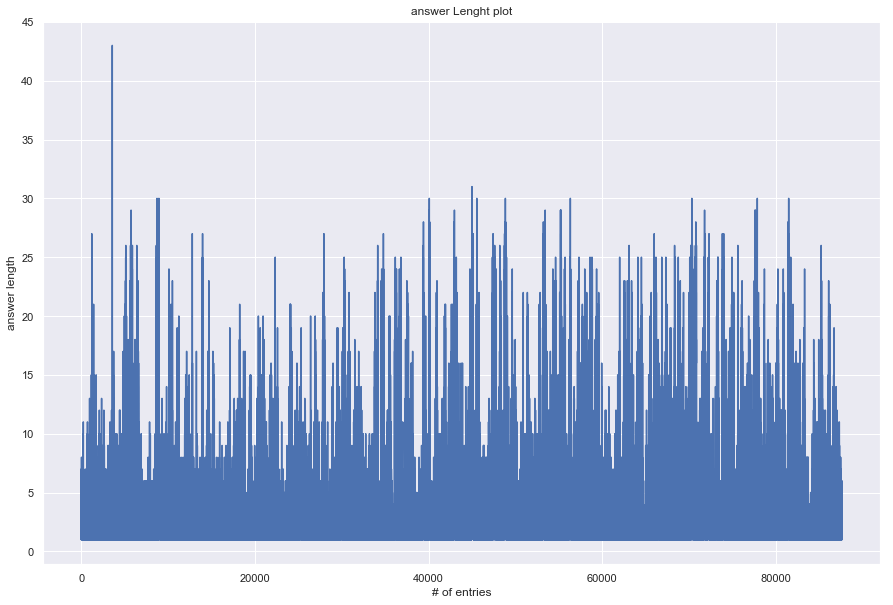

```python
plt.figure(figsize=(15,10))
plt.plot(train["answer_length"])
plt.xlabel("# of entries")
plt.ylabel("answer length")
plt.yticks(range(0,50,5))
plt.title("answer Lenght plot")
plt.show()
```

```python
train["answer_length"].describe()
```

[output not shown]

**Observations:**